# Exploring the BRFSS data

## Clement Lefevre 5th April 2017

### Load packages

```r
library(ggplot2)
library(dplyr)
library(tidyr)
library(forcats)
library(RColorBrewer)
source('multiplot.r')
```

### Load data

Make sure your data and R Markdown files are in the same directory. When loaded your data file will be called `brfss2013`. Delete this note when before you submit your work.

```r
load("brfss2013.RData")
```

## Part 1: Data

The data used for the research has been collected by the Centers for Disease Control and Prevention (CDC) and US States for the year 2013. This study aimed at analysing behavioral risk factors and preventive health practices and the related health condition. There are 330 variables and 491775 subjects in the 2013 data file. Thoses variables contains informations related to :

- demographics and social context,
- health care access,
- behavioral features (e.g. tobacco use, physical activity),
- current health condition,
- pathology screening.

#### Cases

The cases are non-institutionalized adults residing in the US.

#### Sampling methodology

Interviews are either via landline of cell phone. For landline calls, a stratified sampling process has been used for the selection of the number : 1 stratum for high density numbers; an other for medium density. On top of this sampling technique, the landlines calls have sampled with one randomly selected adult ofr for each household.

For cell calls, a simple random sampling based on the phone number, for person receiving 90% or more of the calls per cell phone.

#### Scope of inference

Since the study does consist in a telephone survey on randomly selected adults and no treatments is randomly assigned to the subjects, we can considere it as an **observational study**.

Therefore we can conclude on **associations** but not on causality between the explanatory variables (behavior and practices) and the response (health condition).

From those points we can infer that the results observed in this study can be **generalizable** on the non-institutionalized adults residing in the US, but no causality can be drawn.

## Part 2: Research questions

**Research question 1:**

Quantity of sleep is a factor of good health. Both tobacco use and alcohol consumption are not. I’d like to figure out whether smoking and drinking are somehow related to the length of sleep.

**Is there an association between the quantity of sleep `sleptim1`, tobacco use frequency `smokday2` and alcohol consumtion `avedrnk2` ?**

**Research question 2:**

Veteran population in the US has kept stable since the 70’s. But with both the afghan and iraqi campaigns, a new wave of veterans ermerged. Although the ratio of veterans in the overall pôpulation decreased from 12.8% in 1960 to 7% in 2010 (source : [US census bureau](http://www.pbs.org/newshour/rundown/by-the-numbers-veterans-in-congress/)), the average age might have decreased.

**Are veterans `veteran3` more likely to be single `marital` and more prone to be in poor health `poorhlth` ?**

**Research question 3:**

Eating fruits and fastening the seatbelt are both part of a self-preservation behaviour. It might be interesting to see if those two variables are related.

**Are people eating more fruit `fruit1` more likely to use their seatbelt `seatbelt` ?**

## Part 3: Exploratory data analysis

**Research question 1:** **Is there an association between the quantity of sleep `sleptim1`, tobacco use frequency `smokday2` and alcohol consumtion `avedrnk2` ?**

I set a simple function to check the proportion of non-answered question for each of the selected variable :

```r
# useful method to check the NA ratio in the features
NA.ratio <- function(df,cols){
  df_selected <- df %>% select(one_of(cols))
  print ('missing answer ratio % : ')
  colMeans(is.na(df_selected))*100
   }
```

We can check the ratio of NA for each features :

```r
features_1 <- c("sleptim1","smokday2","avedrnk2")
NA.ratio(brfss2013,features_1)
```

```
## [1] "missing answer ratio % : "
```

```
## sleptim1 smokday2 avedrnk2
##  1.50211 56.32312 52.98968
```

```r
df_q1<-brfss2013 %>% select(one_of(features_1)) %>% na.omit()
```

OK, it seems reasonable. We can proceed further.

Let’s look for outliers :

```r
summary(df_q1)
```

```
##     sleptim1            smokday2        avedrnk2
##  Min.   : 1.000   Every day :27323   Min.   : 1.000
##  1st Qu.: 6.000   Some days :11687   1st Qu.: 1.000
##  Median : 7.000   Not at all:72694   Median : 2.000
##  Mean   : 7.014                      Mean   : 2.492
##  3rd Qu.: 8.000                      3rd Qu.: 3.000
##  Max.   :24.000                      Max.   :76.000
```

Now let’s have a first glance of the distribution of each variable :

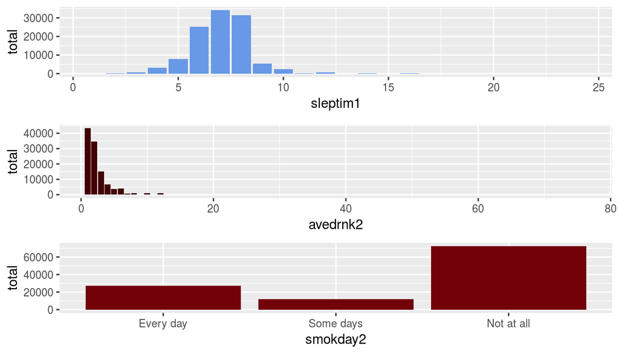

```r
group_sleeptime<- df_q1 %>% group_by(sleptim1) %>% summarise(total =n())
group_smoke <- df_q1 %>% group_by(smokday2) %>% summarise(total=n())
group_alcohol <- df_q1 %>% group_by(avedrnk2) %>% summarise(total=n())

p1<- ggplot(data= group_sleeptime,aes(x=sleptim1,y=total))+ geom_bar(stat="identity", fill="#6899e6")
p2<- ggplot(data= group_alcohol,aes(x=avedrnk2,y=total))+ geom_bar(stat="identity", fill="#420105")
p3<- ggplot(data= group_smoke,aes(x=smokday2,y=total))+ geom_bar(stat="identity", fill="#730109")

layout <- matrix(c(1,2,3), nrow = 3, byrow = TRUE)
  multiplot(p1,p2,p3,cols=1,layout=layout)
```

```r
df_q1<- df_q1 %>% filter(sleptim1<quantile(sleptim1,.995)) %>% filter(avedrnk2<quantile(avedrnk2,.995))
summary(df_q1)
```

```
##     sleptim1            smokday2        avedrnk2
##  Min.   : 1.000   Every day :26626   Min.   : 1.000
##  1st Qu.: 6.000   Some days :11425   1st Qu.: 1.000
##  Median : 7.000   Not at all:72035   Median : 2.000
##  Mean   : 6.971                      Mean   : 2.349
##  3rd Qu.: 8.000                      3rd Qu.: 3.000
##  Max.   :11.000                      Max.   :14.000
```

Let’s plot again :

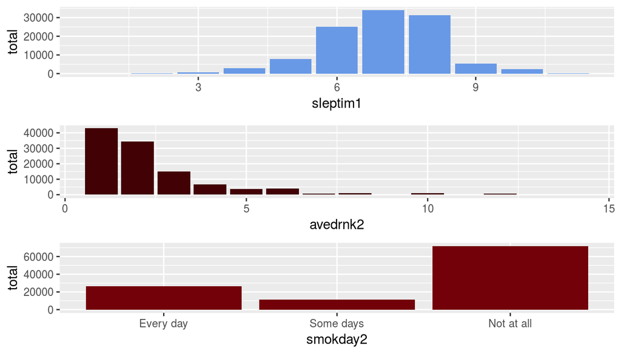

```r
group_sleeptime<- df_q1 %>% group_by(sleptim1) %>% summarise(total =n())
group_smoke <- df_q1 %>% group_by(smokday2) %>% summarise(total=n())
group_alcohol <- df_q1 %>% group_by(avedrnk2) %>% summarise(total=n())

p1<- ggplot(data= group_sleeptime,aes(x=sleptim1,y=total))+ geom_bar(stat="identity", fill="#6899e6")
p2<- ggplot(data= group_alcohol,aes(x=avedrnk2,y=total))+ geom_bar(stat="identity", fill="#420105")
p3<- ggplot(data= group_smoke,aes(x=smokday2,y=total))+ geom_bar(stat="identity", fill="#730109")

layout <- matrix(c(1,2,3), nrow = 3, byrow = TRUE)
  multiplot(p1,p2,p3,cols=1,layout=layout)
```

OK, it’s looks better.

We can now first visualize the relationship between **sleep time** and **smoking** :

```r
group2<-df_q1 %>% group_by(sleptim1,smokday2) %>% summarise(total=n())
group2
```

```
## Source: local data frame [33 x 3]
## Groups: sleptim1 [?]
##
##    sleptim1   smokday2 total
##       <int>     <fctr> <int>
## 1         1  Every day    13
## 2         1  Some days     5
## 3         1 Not at all    12
## 4         2  Every day    83
## 5         2  Some days    31
## 6         2 Not at all    51
## 7         3  Every day   299
## 8         3  Some days   100
## 9         3 Not at all   247
## 10        4  Every day  1255
## # ... with 23 more rows
```

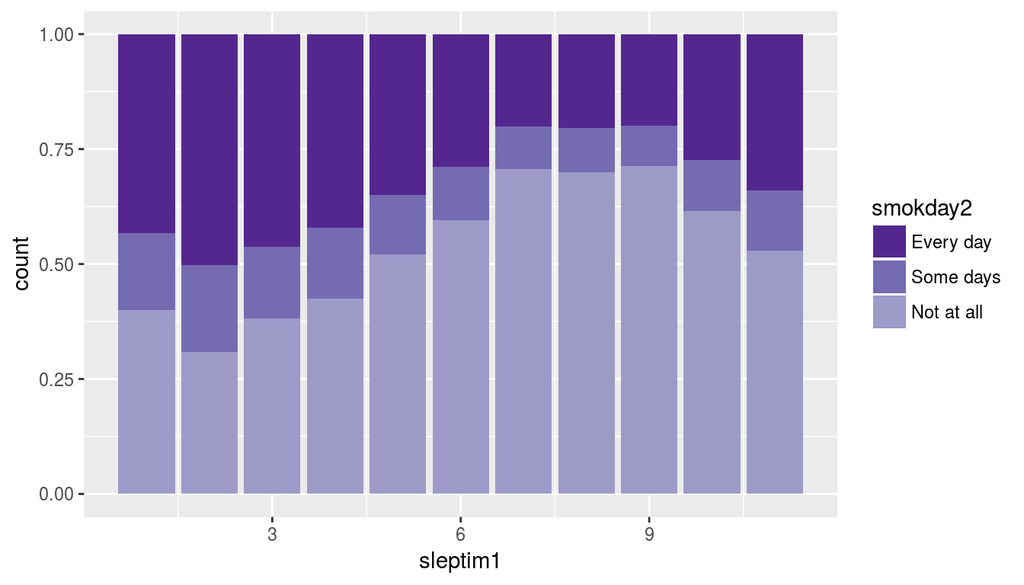

```r
ggplot(group2, aes(x = sleptim1)) + geom_bar(aes(weight=total, fill =smokday2), position = 'fill')  + scale_fill_manual(values = rev(brewer.pal(6, "Purples")))
```

The **smokers** tends to **sleep less** than the rest of population.

How about sleeptime and alcohol consumption ?

We can group the dataset per alcohol consumption level and compute the mean sleep time for each group.

```r
mean_overall_sleptim1= mean(df_q1$sleptim1)

group_avedrnk2_mean_sleep <- df_q1 %>% group_by(avedrnk2) %>% summarise(mean_sleep = mean(sleptim1), pop_size = n())
group_avedrnk2_mean_sleep
```

```
## # A tibble: 14 × 3
##    avedrnk2 mean_sleep pop_size
##       <int>      <dbl>    <int>
## 1         1   7.043277    43071
## 2         2   6.998719    34353
## 3         3   6.918698    14932
## 4         4   6.868749     6659
## 5         5   6.805642     3545
## 6         6   6.750190     3943
## 7         7   6.583474      593
## 8         8   6.791186      953
## 9         9   6.484848      132
## 10       10   6.639791      955
## 11       11   7.000000       15
## 12       12   6.599073      863
## 13       13   6.357143       28
## 14       14   6.340909       44
```

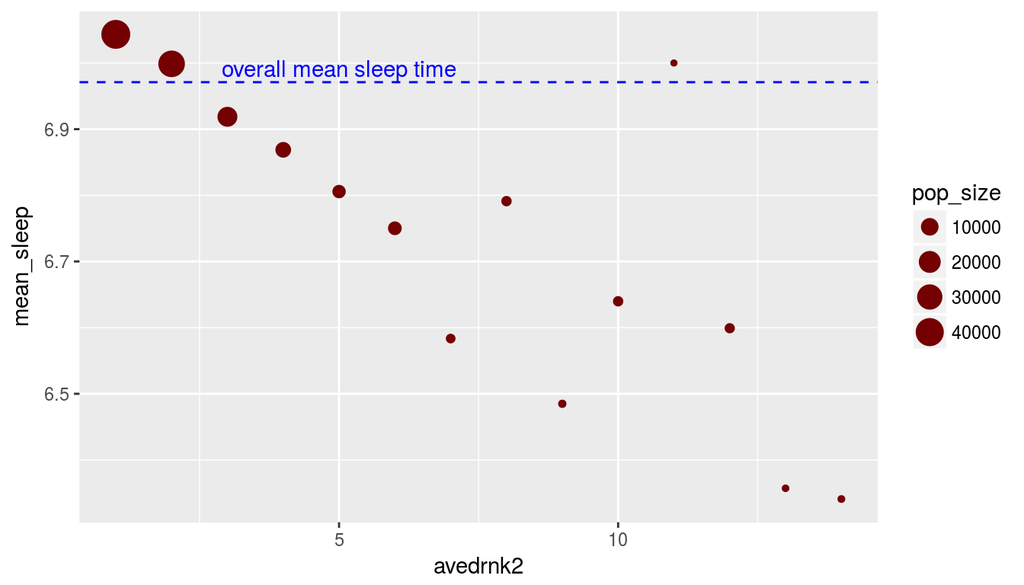

```r
ggplot(group_avedrnk2_mean_sleep,aes(x=avedrnk2,y=mean_sleep,size=pop_size))+geom_point(colour="#740001")+geom_hline(yintercept = mean_overall_sleptim1,colour="blue", linetype="dashed")+annotate("text", x=5, y=mean_overall_sleptim1*1.003, label="overall mean sleep time", color = "blue")
```

It does look like the **more people drink**, the **less they sleep**.

Now we can combine the three variables :

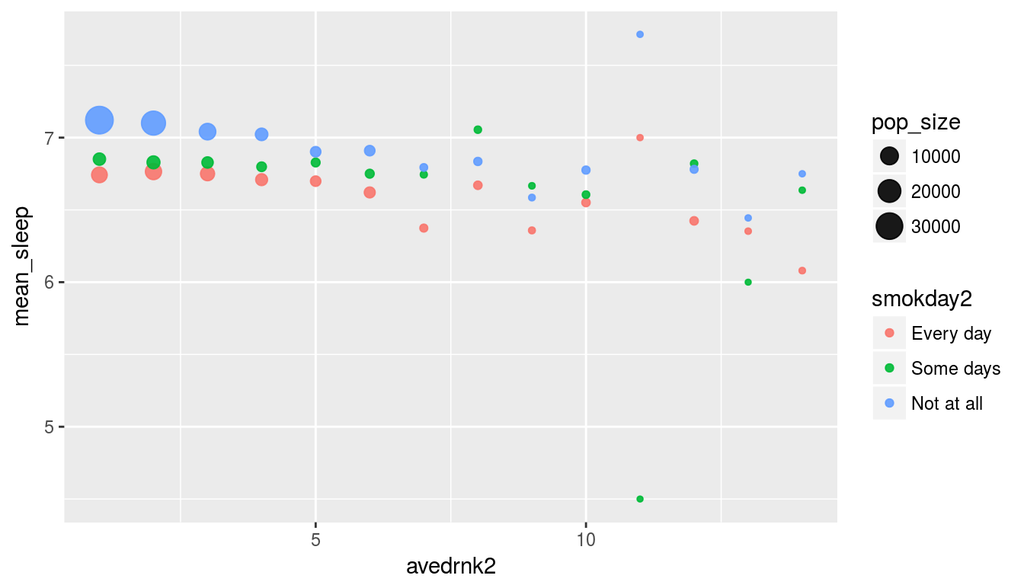

```r
group_avedrnk2_smoke8sleep <- df_q1 %>%group_by(avedrnk2,smokday2) %>% summarise(mean_sleep = mean(sleptim1), pop_size = n())
ggplot(group_avedrnk2_smoke8sleep,aes(x=avedrnk2,y=mean_sleep,size=pop_size,fill=smokday2,color=smokday2))+geom_point(alpha=.9)
```

**Research question 2:** Are veterans `veteran3` more likely to be single `marital` and more prone to be in poor health `poorhlth` ?

```r
features_2 <- c("veteran3","marital","poorhlth")
NA.ratio(brfss2013,features_2)
```

```
## [1] "missing answer ratio % : "
```

```
##   veteran3    marital   poorhlth
##  0.1516954  0.6954400 49.4439530
```

```r
df_q2<-brfss2013 %>% select(one_of(features_2)) %>% na.omit()
df_q2<- df_q2 %>% mutate( marital = fct_recode(marital, "unmarried couple" ="A member of an unmarried couple" ))
```

Answer ratio is still good, we proceed further.

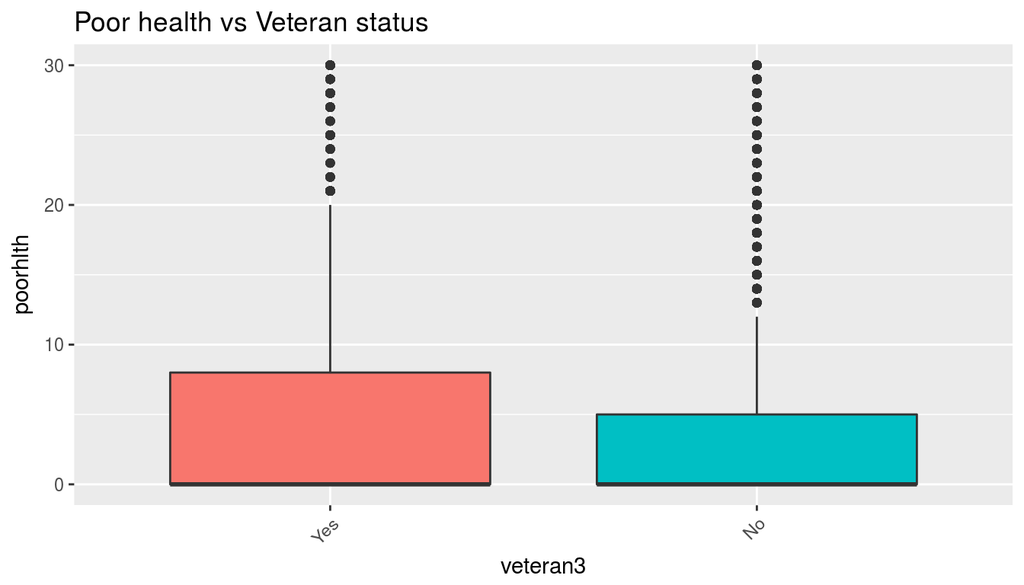

```r
ggplot(data=df_q2, aes(x=veteran3,y=poorhlth,fill=veteran3)) + geom_boxplot()+theme(axis.text.x=element_text(angle=45, hjust=1)) +  labs(title = "Poor health vs Veteran status")+ theme(legend.position="none")
```

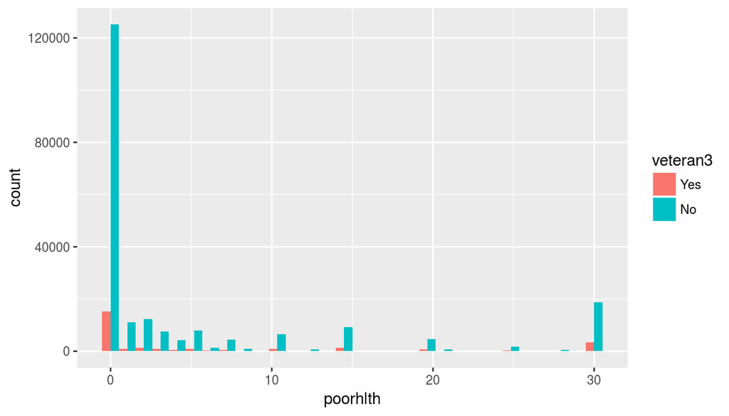

```r
ggplot(data=df_q2,aes(x=poorhlth, fill=veteran3)) + geom_histogram(position='dodge')
```

As a first approach, veterans seem likely to be in poorer health than the rest of the population.

this is confirmed with the following summary :

```r
df_q2 %>% group_by(veteran3) %>% summarise(mean(poorhlth), median(poorhlth),sd(poorhlth))
```

```
## # A tibble: 2 × 4
##   veteran3 `mean(poorhlth)` `median(poorhlth)` `sd(poorhlth)`
##     <fctr>            <dbl>              <dbl>          <dbl>
## 1      Yes         6.353279                  0       10.37482
## 2       No         5.131029                  0        9.26000
```

The median poorhealth for both group is 0. The overwhelming part of both group has no poor health.

Let’s focus on the rest of the population :

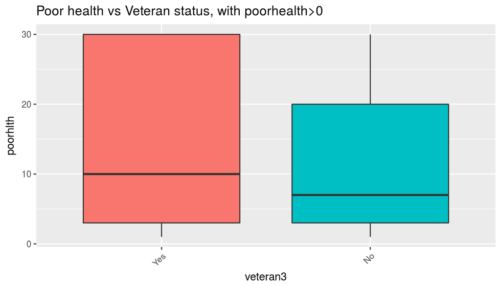

```r
df_q2_poorhealth<-df_q2 %>% filter(poorhlth>0)
ggplot(data=df_q2_poorhealth, aes(x=veteran3,y=poorhlth,fill=veteran3)) + geom_boxplot()+theme(axis.text.x=element_text(angle=45, hjust=1)) +  labs(title = "Poor health vs Veteran status, with poorhealth>0")+ theme(legend.position="none")
```

Now it is clear that veterans are suffering worst health than the others.

But how about the marital status ?

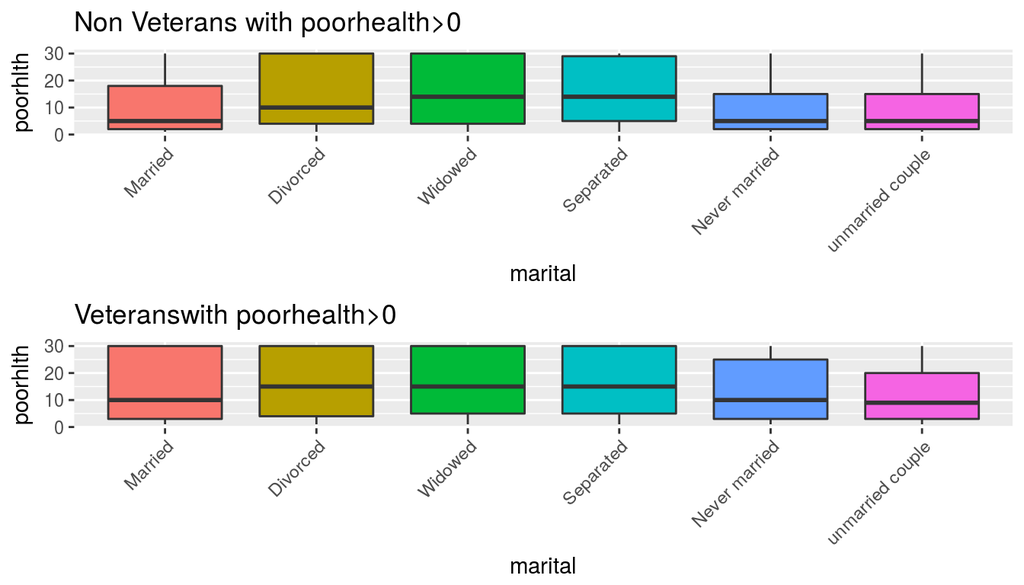

```r
p1<-ggplot(data=df_q2_poorhealth %>% filter(veteran3=='No'), aes(x=marital,y=poorhlth,fill=marital)) + geom_boxplot()+theme(axis.text.x=element_text(angle=45, hjust=1)) +  labs(title = "Non Veterans with poorhealth>0")+ theme(legend.position="none")
p2<-ggplot(data=df_q2_poorhealth %>% filter(veteran3=='Yes'), aes(x=marital,y=poorhlth,fill=marital)) + geom_boxplot()+theme(axis.text.x=element_text(angle=45, hjust=1))+  labs(title = "Veteranswith poorhealth>0") + theme(legend.position="none")

 layout <- matrix(c(1,2), nrow = 2, byrow = TRUE)
  multiplot(p1,p2,cols=2,layout=layout)
```

How about the veterans age factor ?

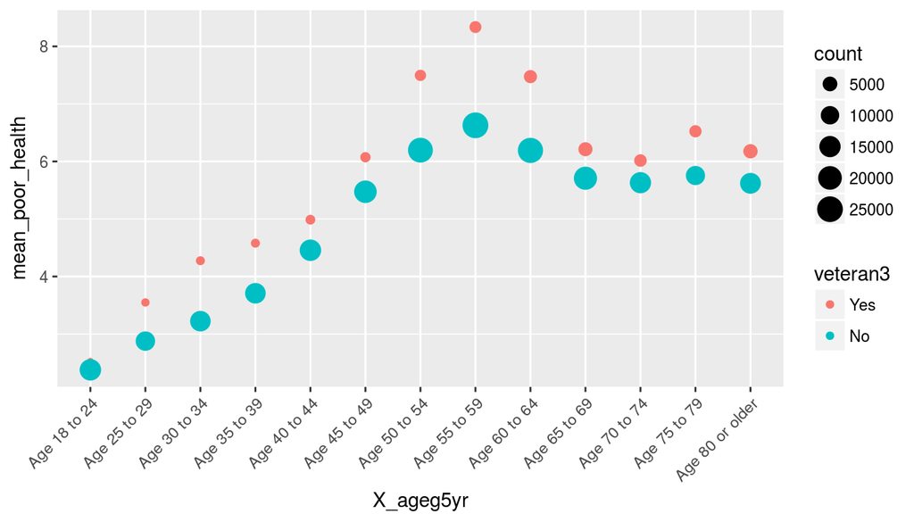

```r
df_q2_age_health_veterans <- brfss2013 %>% select(poorhlth,veteran3,X_ageg5yr) %>% na.omit()

groupy<-df_q2_age_health_veterans %>% group_by(veteran3,X_ageg5yr) %>% summarise(mean_poor_health=mean(poorhlth), count= n())

ggplot(groupy,aes(x=X_ageg5yr, y=mean_poor_health, color=veteran3,size=count)) +geom_point()+theme(axis.text.x=element_text(angle=45, hjust=1))
```

The result is quite clear :

- the oldest verteran age class (World war II) show a gap with their non-veteran counterpart.
- the **Vietnam war veterans** are in a much worst shape than their non-veterans equivalents.
- the Iraq and Afghan vets suffers poor health also, but not as strongly as the Vietnam veterans.

**Research question 3:**

**Are people eating more fruit `fruit1` more likely to use their seatbelt `seatbelt` ?**

In this case, the `fruit1` variable has to be a little bit reworked. Looking a the `fruit1` definition in the 2013 BRFSS Codebook report :

[output not shown]

We can define categories rather than numeric values :

```r
categorize_fruits <- function(cell){
  if(cell==300){
    return("4_< Once in month")
  }
      if(cell<400 & cell>100){
    group<-cell%/%100
     return(switch(group,'1_day','2_week','3_month'))
  } else{
    return("5_NA")
  }
  }
```

We can now apply this function to the dataset :

```r
fruit_and_seatbelt <-brfss2013 %>% select(fruit1,seatbelt) %>% na.omit() %>% rowwise()  %>%mutate(fruit_group =categorize_fruits(fruit1))  %>%ungroup()
```

And then group the data per fruit consumption category and seatbelt fasteners :

```r
groupy<- fruit_and_seatbelt %>% filter(fruit_group!="5_NA") %>% group_by(fruit_group,seatbelt) %>% summarise(count=n()) %>% mutate(ratio=count/sum(count))
```

Finally, we get a plot :

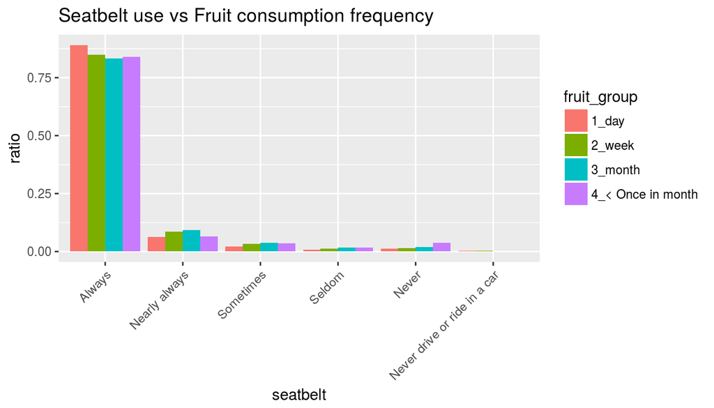

```r
ggplot(arrange(groupy,fruit_group), aes(seatbelt, ratio)) +  geom_bar(aes(fill = fruit_group), position = "dodge", stat="identity")+theme(axis.text.x=element_text(angle=45, hjust=1))+ labs(title = "Seatbelt use vs Fruit consumption frequency")
```

Interestingly enough, people eating **no fruits or seldomly tend to skip the use of a seatbelt more often** than the others. And the opposite is also true : **fruit eaters do fasten their buckles more systematically.**

*I hope you did enjoy this short presentation.*